# html

## Load Data

```python
import pandas as pd
import numpy as np

user_activity = pd.read_csv('https://storage.googleapis.com/datalynn-datasets/interview-challenge/technology/TikTok_User_Churn/user_activity.csv')
user_demographics = pd.read_csv('https://storage.googleapis.com/datalynn-datasets/interview-challenge/technology/TikTok_User_Churn/user_demographics.csv')
churn_prediction = pd.read_csv('https://storage.googleapis.com/datalynn-datasets/interview-challenge/technology/TikTok_User_Churn/churn_prediction.csv')
```

### Question 1

**Scenario**: You've noticed some inconsistencies in the `last_login` column of the User Activity Table, hinting at inactive users.

- Identify users who haven't logged in for the last 30 days and rank them based on their `followers_count`. Utilizing the Demographics table, what patterns do you observe amongst the top-ranked users in terms of `country` and `account_duration`?

**Problem Solving Ideas and Tips:**

- The first step is to filter out the users who haven't logged in for the last 30 days. This can be derived from the `last_login` column in the `user_activity` table.
- Once we've identified these users, we should rank them based on their `followers_count`.
- After ranking, we will join with the `user_demographics` table to understand the patterns related to the `country` and `account_duration` of the top-ranked users.

```python
import sqlite3

# Convert dataframes to SQL tables
conn = sqlite3.connect(":memory:")
user_activity.to_sql('user_activity', conn, index=False)
user_demographics.to_sql('user_demographics', conn, index=False)

sql_query = """
WITH InactiveUsers AS (
    SELECT
        user_id,
        last_login,
        followers_count,
        RANK() OVER (ORDER BY followers_count DESC) AS rank_by_followers
    FROM user_activity
    WHERE julianday('2023-07-31') - julianday(last_login) > 30
)

SELECT
    i.user_id,
    i.last_login,
    i.followers_count,
    i.rank_by_followers,
    d.country,
    d.account_duration
FROM InactiveUsers i
JOIN user_demographics d ON i.user_id = d.user_id
ORDER BY i.rank_by_followers;
"""

top_inactive_users = pd.read_sql_query(sql_query, conn)
conn.close()

top_inactive_users.head(10)
```

|  | user_id | last_login | followers_count | rank_by_followers | country | account_duration |
| --- | --- | --- | --- | --- | --- | --- |
| 0 | 4119 | 2023-06-02 | 43212 | 1 | Russia | 552 |
| 1 | 174 | 2023-06-02 | 39756 | 2 | Indonesia | 926 |
| 2 | 3828 | 2023-06-02 | 39575 | 3 | US | 910 |
| 3 | 1562 | 2023-06-02 | 39090 | 4 | US | 576 |
| 4 | 865 | 2023-06-02 | 37537 | 5 | India | 410 |
| 5 | 2886 | 2023-06-02 | 37204 | 6 | Russia | 385 |
| 6 | 2590 | 2023-06-02 | 36791 | 7 | India | 287 |
| 7 | 3331 | 2023-06-02 | 35180 | 8 | Brazil | 477 |
| 8 | 2769 | 2023-06-02 | 34917 | 9 | US | 175 |
| 9 | 3148 | 2023-06-02 | 34775 | 10 | US | 981 |

### Question 2

**Scenario**: We're diving deeper into patterns of user engagement related to churn.

- Given the User Activity and Churn Prediction tables, assess the probability that a user with above-average `avg_watch_time` but below-average `likes_received` will churn. Can you draw any statistical correlations between `video_uploads` and the churn probability?

**Problem Solving Ideas and Tips:**

- First, you'll want to determine the average `avg_watch_time` and `likes_received` from the `user_activity` table.
- Then, filter users based on the criteria: above-average `avg_watch_time` and below-average `likes_received`.
- After filtering, join this set with the `churn_prediction` table to understand the churn probability.
- Finally, use statistical tests or correlation methods to understand the relationship between `video_uploads` and `predicted_churn`.

```python
avg_watch_time = user_activity['avg_watch_time'].mean()
avg_likes = user_activity['likes_received'].mean()

filtered_df = user_activity[(user_activity['avg_watch_time'] > avg_watch_time) &
                            (user_activity['likes_received'] < avg_likes)]
merged_df = pd.merge(filtered_df, churn_prediction, on='user_id', how='inner')

churn_probability = merged_df['predicted_churn'].mean()

# Assess correlation between video_uploads and churn prediction
correlation = merged_df['video_uploads'].corr(merged_df['predicted_churn'])

print("Churn Probability:", churn_probability)
print("Correlation between video_uploads and churn prediction:", correlation)
```

```
Churn Probability: 0.3302292263610315
Correlation between video_uploads and churn prediction: 0.4307006904282102
```

### Question 3:

*Scenario*: Past behavior often sheds light on future actions.

- Construct a model to predict churn using the User Activity and Demographics tables. How does the `previous_churns` feature influence predictions? How would you avoid overfitting and which features would be most influential in the model?

**Problem Solving Ideas and Tips:**

1. Merge the User Activity and Demographics tables using the user_id as the key.
2. Split the dataset into training and testing sets.
3. Use a model, such as a Random Forest Classifier or Gradient Boosting, to predict churn.
4. Train the model and evaluate its performance using accuracy, precision, recall, and the ROC-AUC score.
5. Feature importance can give insight into which features are most influential in predicting churn.
6. Regularization techniques, cross-validation, or pruning can be used to avoid overfitting.

```
Accuracy: 0.8990
Precision: 0.9009
Recall: 0.8152
ROC AUC Score: 0.8815
```

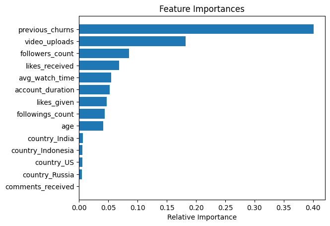

```python
import matplotlib.pyplot as plt
from sklearn.ensemble import RandomForestClassifier
from sklearn.model_selection import train_test_split
from sklearn.metrics import accuracy_score, precision_score, recall_score, roc_auc_score

# Step 1: Merge tables
merged_data = pd.merge(user_activity, user_demographics, on='user_id')
final_data = pd.merge(merged_data, churn_prediction[['user_id', 'predicted_churn']], on='user_id')

# Encoding 'country' categorical variable
final_data = pd.get_dummies(final_data, columns=['country'], drop_first=True)

# Step 2: Split data into training and testing
X = final_data.drop(columns=['user_id', 'last_login', 'predicted_churn'])
y = final_data['predicted_churn']
X_train, X_test, y_train, y_test = train_test_split(X, y, test_size=0.2, random_state=42)

# Step 3: Train a RandomForest model
clf = RandomForestClassifier(random_state=42)
clf.fit(X_train, y_train)

# Step 4: Evaluate model performance
y_pred = clf.predict(X_test)
print(f"Accuracy: {accuracy_score(y_test, y_pred):.4f}")
print(f"Precision: {precision_score(y_test, y_pred):.4f}")
print(f"Recall: {recall_score(y_test, y_pred):.4f}")
print(f"ROC AUC Score: {roc_auc_score(y_test, y_pred):.4f}")

# Step 5: Feature Importance
importances = clf.feature_importances_
indices = np.argsort(importances)

plt.title('Feature Importances')
plt.barh(range(len(indices)), importances[indices], align='center')
plt.yticks(range(len(indices)), [X.columns[i] for i in indices])
plt.xlabel('Relative Importance')
plt.show()
```

The output:

- Provides accuracy, precision, recall, and the ROC-AUC score of the model.
- A bar plot indicating the importance of each feature. The higher the bar, the more important the feature.

From this analysis:

- You can gauge how the `previous_churns` feature influences predictions by looking at its relative importance in the plot.
- Overfitting can be reduced by tuning hyperparameters, such as the number of trees, max depth of trees, or by using a validation set or techniques like cross-validation.
- The features with the highest bars in the plot are the most influential in the model.

### Question 4

*Scenario*: Strategies should be backed by data-driven insights.

- Examining the Churn Prediction table and drawing insights from the User Demographics table, which segment of users, identified by a particular country or age range, seems most likely to churn? Propose a modification or feature targeting this segment to boost retention. How would A/B testing be applied to gauge the new feature's impact?

**Problem Solving Ideas and Tips** To solve this question, we'll go through the following steps:

1. Join the Churn Prediction and User Demographics tables to link user demographic info with churn prediction.
2. Aggregate churn rates by country and by age range to identify the highest risk segments.
3. Propose a new feature targeting the identified segment.
4. Design an A/B test for the proposed feature.

**1. Joining Churn Prediction and User Demographics Tables**

**2. Aggregate Churn Rates by Country and Age Range**

By following the above solution, one can use data-driven insights to develop strategies that can enhance user retention and growth on TikTok.

```python
# 1. Joining Churn Prediction and User Demographics Tables
churn_with_demographics = pd.merge(churn_prediction, user_demographics, on='user_id')

# 2. Aggregate Churn Rates by Country and Age Range
# By country
country_churn = churn_with_demographics.groupby('country').mean()['predicted_churn']

# By age range
bins = [15, 20, 30, 40, 50]
labels = ['15-20', '20-30', '30-40', '40-50']
churn_with_demographics['age_range'] = pd.cut(churn_with_demographics['age'], bins=bins, labels=labels, right=False)
age_churn = churn_with_demographics.groupby('age_range').mean()['predicted_churn']

print(country_churn, '\n', age_churn)
```

```
country
Brazil       0.392562
India        0.350993
Indonesia    0.371957
Russia       0.371901
US           0.349833
Name: predicted_churn, dtype: float64
 age_range
15-20    0.385321
20-30    0.364118
30-40    0.374011
40-50    0.335366
Name: predicted_churn, dtype: float64
```